# Regression Research for Dynamics Variables (Top 10 Tech Clusters)

# Current Question

1. I used multiple linear regression for the this research. Did the following OLS estimation you wrote in the last communication use the time series forecasting model such as ARIMA OLS estimation? Do I need to use time series forecasting to estimate?

   Dynamics_variable_it = a1 + b2#firms_it-n + b3industry mix_it-n + Xb_it-n + location_i + year_t + e_it (1)

   Firm_performance_it = c1 + c2#firms_it-n + c3dynamics_it-n + c4industry mix_it-n + Xc_it-n + location_i + year_t + u_it (2)

   P.S. I found that Firm_performance_it is also only available for `Average_of_latest_accounts_assets` in the dataset. OR are there other indicators that can be used to measure Firm_performance_it
2. HIH index might not be available because a company’s market share is difficult to measure for the existing dataset

# 1 Key Results

My Research Question:

- How does tech clusters' dynamics pattern change in UK from 1998 to 2018? / What factors can affect tech clusters' dynamics pattern change in UK?
- To what extent will dynamic changes affect tech clusters’ performance？

## 1.2 Data

Below is my dataset for regression research, you can access/download it in this [link](https://zeqiang.fun/CASA0012-Dissertation/dataset/Top_10_Tech_TTWA_Cluster_Reg_Prepare.xlsx)

```python
df3.head()
```

|  | ttwa | birth_year | Count_of_tech_firms | Average_of_latest_accounts_assets | Total_tech_firms | Entry_Rate |
| --- | --- | --- | --- | --- | --- | --- |
| 0 | E30000169 | 1998 | 57 | 154,110.7632 | 9047 | 0.0063 |
| 1 | E30000169 | 1999 | 78 | 392,610.4737 | 9047 | 0.0086 |
| 2 | E30000169 | 2000 | 82 | 234,658.3898 | 9047 | 0.0091 |
| 3 | E30000169 | 2001 | 67 | 198,533.5192 | 9047 | 0.0074 |
| 4 | E30000169 | 2002 | 125 | 169,835.2778 | 9047 | 0.0138 |

## 1.3 Hypothesis

With reference to the OLS estimation that you said last time, I made two assumptions in section 2.3 Hypothesis. I selected the second assumption as following key results:

$\ log_e{\ Dynamics\ Variable_{i,t}}\ =\ a_1 + b_1 \times firms_{i,t} + b_2 \times location_i + b_3 \times year_t$ (1)

$\ log_e\ Firm\ Performance_{i,t}\ =\ c_1 + d_1 \times firms_{i,t} + d_2 \times dynamics_{i,t} + d_3 \times location_i + d_4 \times year_t$ (2)

- $Dynamics\ Variable_{i,t}$ in (1) means `Entry_Rate` in $t$ and $i$
- $dynamics_{i,t}$ in (2) means `Entry_Rate` in a specific $t$ and $i$
- $firms_{i,t}$ means `Count_of_tech_firms` in a specific $t$ and $i$
- $t$ means year -- `birth_year`
- $i$ means location -- `ttwa` (travel to work area)

## 1.4 Regression

For the multiple linear regression of the above assumptions, the final results are given below; the goodness of model fit is not bad ($R^2$ is high)

$\ log_e{\ Dynamics\ Variable_{i,t}} = 2.8e^{-5} \times firms_{i,t} + b_2 \times location_i + 0.15 \times year_t - 310$（1）

$\ log_e\ Firm\ Performance_{i,t}\ = 0.0001 \times firms_{i,t} + {-8.9585} \times dynamics_{i,t} + d_3 \times location_i + {-0.0675} \times year_t + 147.5$ (2)

NOTE: $b_2$ and $d_3$ should be seen in the following regression summary because $location_i$ is a dummy independent variable.

The regression report details are given below (Report No.1 & No.2), and further residual analysis can be viewed in section 2.4.2

**【Report No.1】**

This is the **Dynamics Variable (1)** regression summary:

NOTE: for dummy variable $location_i$, `ttwa_E30000169（Birmingham）` is dropped as a reference objectivity in the regression

```python
# for formula (1)
hypo2_1_regressor_OLS.summary()
```

OLS Regression Results

| Dep. Variable: | Entry_Rate | R-squared: | 0.932 |
| --- | --- | --- | --- |
| Model: | OLS | Adj. R-squared: | 0.928 |
| Method: | Least Squares | F-statistic: | 238.5 |
| Date: | Tue, 27 Jul 2021 | Prob (F-statistic): | 3.43e-105 |
| Time: | 00:49:45 | Log-Likelihood: | -9.0648 |
| No. Observations: | 203 | AIC: | 42.13 |
| Df Residuals: | 191 | BIC: | 81.89 |
| Df Model: | 11 |  |  |
| Covariance Type: | nonrobust |  |  |

|  | coef | std err | t | P>\|t\| | [0.025 | 0.975] |
| --- | --- | --- | --- | --- | --- | --- |
| const | -310.4470 | 6.992 | -44.399 | 0.000 | -324.239 | -296.655 |
| birth_year | 0.1529 | 0.003 | 43.878 | 0.000 | 0.146 | 0.160 |
| Count_of_tech_firms | 2.804e-05 | 1.13e-05 | 2.489 | 0.014 | 5.82e-06 | 5.03e-05 |
| ttwa_E30000175 | -0.4938 | 0.082 | -5.986 | 0.000 | -0.657 | -0.331 |
| ttwa_E30000179 | -0.1491 | 0.082 | -1.829 | 0.069 | -0.310 | 0.012 |
| ttwa_E30000180 | 0.1377 | 0.082 | 1.669 | 0.097 | -0.025 | 0.300 |
| ttwa_E30000186 | 0.1193 | 0.083 | 1.446 | 0.150 | -0.043 | 0.282 |
| ttwa_E30000212 | 0.2416 | 0.083 | 2.928 | 0.004 | 0.079 | 0.404 |
| ttwa_E30000234 | -0.2003 | 0.099 | -2.028 | 0.044 | -0.395 | -0.005 |
| ttwa_E30000237 | -0.0440 | 0.082 | -0.533 | 0.595 | -0.207 | 0.119 |
| ttwa_E30000239 | 0.0074 | 0.082 | 0.091 | 0.928 | -0.154 | 0.168 |
| ttwa_E30000266 | 0.0248 | 0.083 | 0.300 | 0.765 | -0.138 | 0.188 |

| Omnibus: | 6.590 | Durbin-Watson: | 1.008 |
| --- | --- | --- | --- |
| Prob(Omnibus): | 0.037 | Jarque-Bera (JB): | 6.880 |
| Skew: | 0.316 | Prob(JB): | 0.0321 |
| Kurtosis: | 3.643 | Cond. No. | 1.04e+06 |

Notes:  
[1] Standard Errors assume that the covariance matrix of the errors is correctly specified.  
[2] The condition number is large, 1.04e+06. This might indicate that there are  
strong multicollinearity or other numerical problems.

**【Report No.2】**

This is the **Firms' Performance (2)** regression summary:

```python
# for formula (2)

hypo2_2_regressor_OLS.summary()
```

OLS Regression Results

| Dep. Variable: | Average_of_latest_accounts_assets | R-squared: | 0.745 |
| --- | --- | --- | --- |
| Model: | OLS | Adj. R-squared: | 0.729 |
| Method: | Least Squares | F-statistic: | 46.37 |
| Date: | Tue, 27 Jul 2021 | Prob (F-statistic): | 6.23e-50 |
| Time: | 00:50:00 | Log-Likelihood: | -99.816 |
| No. Observations: | 203 | AIC: | 225.6 |
| Df Residuals: | 190 | BIC: | 268.7 |
| Df Model: | 12 |  |  |
| Covariance Type: | nonrobust |  |  |

|  | coef | std err | t | P>\|t\| | [0.025 | 0.975] |
| --- | --- | --- | --- | --- | --- | --- |
| const | 147.5047 | 22.122 | 6.668 | 0.000 | 103.868 | 191.142 |
| birth_year | -0.0675 | 0.011 | -6.111 | 0.000 | -0.089 | -0.046 |
| Count_of_tech_firms | 0.0001 | 1.95e-05 | 5.773 | 0.000 | 7.42e-05 | 0.000 |
| Entry_Rate | -8.9585 | 1.814 | -4.940 | 0.000 | -12.536 | -5.381 |
| ttwa_E30000175 | -0.2359 | 0.129 | -1.823 | 0.070 | -0.491 | 0.019 |
| ttwa_E30000179 | -0.2070 | 0.128 | -1.618 | 0.107 | -0.459 | 0.045 |
| ttwa_E30000180 | 0.0600 | 0.129 | 0.464 | 0.643 | -0.195 | 0.315 |
| ttwa_E30000186 | 0.1323 | 0.129 | 1.023 | 0.308 | -0.123 | 0.387 |
| ttwa_E30000212 | 0.2389 | 0.129 | 1.845 | 0.067 | -0.016 | 0.494 |
| ttwa_E30000234 | 0.0065 | 0.159 | 0.041 | 0.967 | -0.307 | 0.320 |
| ttwa_E30000237 | 0.0750 | 0.129 | 0.580 | 0.563 | -0.180 | 0.330 |
| ttwa_E30000239 | -0.0467 | 0.128 | -0.365 | 0.716 | -0.299 | 0.206 |
| ttwa_E30000266 | 0.0912 | 0.129 | 0.704 | 0.482 | -0.164 | 0.347 |

| Omnibus: | 103.810 | Durbin-Watson: | 1.682 |
| --- | --- | --- | --- |
| Prob(Omnibus): | 0.000 | Jarque-Bera (JB): | 1355.690 |
| Skew: | -1.582 | Prob(JB): | 4.13e-295 |
| Kurtosis: | 15.259 | Cond. No. | 2.11e+06 |

Notes:  
[1] Standard Errors assume that the covariance matrix of the errors is correctly specified.  
[2] The condition number is large, 2.11e+06. This might indicate that there are  
strong multicollinearity or other numerical problems.

For better see the ttwa cluster name:

```python
df_ttwa_10.style
```

|  | ttwa_code | name | counts |
| --- | --- | --- | --- |
| 0 | E30000234 | London | 119008 |
| 1 | E30000239 | Manchester | 18273 |
| 2 | E30000266 | Slough and Heathrow | 17367 |
| 3 | E30000169 | Birmingham | 9593 |
| 4 | E30000237 | Luton | 8873 |
| 5 | E30000175 | Bournemouth | 7546 |
| 6 | E30000179 | Brighton | 7483 |
| 7 | E30000186 | Cambridge | 6252 |
| 8 | E30000180 | Bristol | 6176 |
| 9 | E30000212 | Guildford and Aldershot | 5986 |

## 1.5 Insights

$\ log_e{\ Dynamics\ Variable_{i,t}} = 2.8e^{-5} \times firms_{i,t} + b_2 \times location_i + 0.15 \times year_t - 310$（1）

$\ log_e\ Firm\ Performance_{i,t}\ = 0.0001 \times firms_{i,t} + {-8.9585} \times dynamics_{i,t} + d_3 \times location_i + {-0.0675} \times year_t + 147.5$ (2)

# 2 Reproducible Analysis

## 2.1 Read Data

```python
import pandas as pd
import sys
PATH = sys.path[0]

df = pd.read_csv(PATH + "/Dataset/fame_OC_tech_firm.csv",low_memory=False)
df = df.drop({"Unnamed: 0","Unnamed: 0.1","Unnamed: 0.1.1","is_tech"},axis = 1)

# preprocess the data
# drop the null value record in birth year and ttwa(travel to work area) columns
df = df.dropna(subset = {"birth_year","ttwa"})
```

## 2.2 Data Preparation

Get the top 10 ttwas which have the most number of firms

```python
# Generate the top 10 tech clusters table based on the ttwa
top_10_ttwa = df.ttwa.value_counts().head(10)
top_10_ttwa = pd.DataFrame(top_10_ttwa).reset_index()
top_10_ttwa.columns = ["ttwa_code","counts"]

df_ttwa = pd.read_csv(PATH + "/Dataset/ttwa.csv")
df_ttwa = pd.merge(top_10_ttwa, df_ttwa[["code","name"]], left_on="ttwa_code",right_on="code")
df_ttwa_10 = df_ttwa[["ttwa_code", "name","counts"]]
df_ttwa_10.style
```

|  | ttwa_code | name | counts |
| --- | --- | --- | --- |
| 0 | E30000234 | London | 119008 |
| 1 | E30000239 | Manchester | 18273 |
| 2 | E30000266 | Slough and Heathrow | 17367 |
| 3 | E30000169 | Birmingham | 9593 |
| 4 | E30000237 | Luton | 8873 |
| 5 | E30000175 | Bournemouth | 7546 |
| 6 | E30000179 | Brighton | 7483 |
| 7 | E30000186 | Cambridge | 6252 |
| 8 | E30000180 | Bristol | 6176 |
| 9 | E30000212 | Guildford and Aldershot | 5986 |

**Filter** data by `ttwa`

```python
# df_10_tc means "top 10 tech ttwa clusters"
df_10_tc = df.copy()
print(df_10_tc.shape)

# filter data to top 10 ttwa data raws
df_10_tc = df_10_tc[df_10_tc.ttwa.isin(df_ttwa_10.ttwa_code.to_list())]
print(df_10_tc.shape)
```

```
(423634, 64)
(206557, 64)
```

**Filter** data by `birth_year`

```python
print(df_10_tc.shape)
# df_10_tc_20 means "top 10 tech ttwa clusters in 20 years dataframe"
df_10_tc_20 = df_10_tc[df_10_tc["birth_year"]>=1998]
# data beautify
df_10_tc_20 = df_10_tc_20.reset_index().drop("index",axis=1)
print(df_10_tc_20.shape)
df_10_tc_20.head()
```

```
(206557, 64)
(196071, 64)
```

|  | registered_number | incorporation_date | dissolution_date | latest_accounts_cash | latest_accounts_assets | latest_accounts_liabilities | year_obs | sic_year | sic4 | change_sic | ... | pcd2 | pcds | cty | laua | ctry | rgn | ttwa | pct | lep1 | lep2 |
| --- | --- | --- | --- | --- | --- | --- | --- | --- | --- | --- | --- | --- | --- | --- | --- | --- | --- | --- | --- | --- | --- |
| 0 | 07341142 | 2010-08-10 | NaN | NaN | 56331.0 | NaN | 2017 | 2007.0 | 6202.0 | 0.0 | ... | AL1 1AJ | AL1 1AJ | E10000015 | E07000240 | E92000001 | E12000006 | E30000237 | E16000150 | E37000017 | NaN |
| 1 | 10490667 | 2016-11-22 | NaN | NaN | 11254.0 | NaN | 2018 | 2007.0 | 7211.0 | 0.0 | ... | AL1 1AU | AL1 1AU | E10000015 | E07000240 | E92000001 | E12000006 | E30000237 | E16000150 | E37000017 | NaN |
| 2 | 11283731 | 2018-03-29 | NaN | NaN | NaN | NaN | 2018 | 2007.0 | 6201.0 | 0.0 | ... | AL1 1DG | AL1 1DG | E10000015 | E07000240 | E92000001 | E12000006 | E30000237 | E16000150 | E37000017 | NaN |
| 3 | 09852054 | 2015-11-02 | NaN | NaN | 20002.0 | NaN | 2017 | 2007.0 | 6201.0 | 0.0 | ... | AL1 1DG | AL1 1DG | E10000015 | E07000240 | E92000001 | E12000006 | E30000237 | E16000150 | E37000017 | NaN |
| 4 | 08577485 | 2013-06-20 | NaN | NaN | 8390.0 | 11888.0 | 2017 | 2007.0 | 8621.0 | 0.0 | ... | AL1 1DS | AL1 1DS | E10000015 | E07000240 | E92000001 | E12000006 | E30000237 | E16000150 | E37000017 | NaN |

5 rows × 64 columns

**Select** the necessary columns:

- location: `ttwa`
- year: `birth_year` & `diss_year`
- firms' performance : `latest_accounts_assets`

```python
df2 = df_10_tc_20.copy()

# select data in below columns
df2 = df2[["registered_number",\
        "ttwa",\
        "birth_year",\
        "diss_year",\
        "latest_accounts_assets"]]

df2.head()
```

|  | registered_number | ttwa | birth_year | diss_year | latest_accounts_assets |
| --- | --- | --- | --- | --- | --- |
| 0 | 07341142 | E30000237 | 2,010.0000 | nan | 56,331.0000 |
| 1 | 10490667 | E30000237 | 2,016.0000 | nan | 11,254.0000 |
| 2 | 11283731 | E30000237 | 2,018.0000 | nan | nan |
| 3 | 09852054 | E30000237 | 2,015.0000 | nan | 20,002.0000 |
| 4 | 08577485 | E30000237 | 2,013.0000 | nan | 8,390.0000 |

Export above `df2` into Excel to conduct a pivot operation

```python
# export to excel to process
df2.to_excel(PATH + "/Top_10_Tech_TTWA_Cluster_Reg_Prepare.xlsx", index = False)
```

After doing pivot in Excel, **read** this .xlsx file to get the processed dataset `df3`

```python
df3 = pd.read_excel(PATH + "/Excel/Top_10_Tech_TTWA_Cluster_Reg_Prepare.xlsx",sheet_name = "dynamics")
df3.head()
```

|  | ttwa | birth_year | Count_of_tech_firms | Average_of_latest_accounts_assets | Total_tech_firms | Entry_Rate |
| --- | --- | --- | --- | --- | --- | --- |
| 0 | E30000169 | 1998 | 57 | 154110.763158 | 9047 | 0.006300 |
| 1 | E30000169 | 1999 | 78 | 392610.473684 | 9047 | 0.008622 |
| 2 | E30000169 | 2000 | 82 | 234658.389831 | 9047 | 0.009064 |
| 3 | E30000169 | 2001 | 67 | 198533.519231 | 9047 | 0.007406 |
| 4 | E30000169 | 2002 | 125 | 169835.277778 | 9047 | 0.013817 |

Distribution analysis for the dependent variable `Entry_Rate`

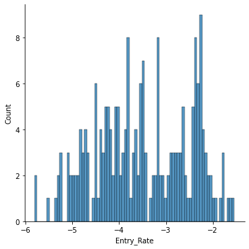

```python
import seaborn as sns
import numpy as np

df_dist = df3.copy()
df_dist.Entry_Rate = np.log(df_dist["Entry_Rate"])
sns.displot(df_dist, x="Entry_Rate",bins=80)
```

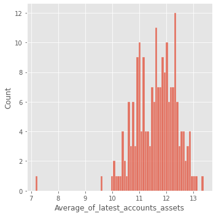

```python
df_dist = df3.copy()
df_dist.Average_of_latest_accounts_assets = np.log1p(df_dist["Average_of_latest_accounts_assets"])
sns.displot(df_dist, x="Average_of_latest_accounts_assets",bins=80)
```

## 2.3 Hypothesis

**Hypothesis 1:**

$\ Dynamics\ Variable_{i,t}\ =\ a_1 + b_1 \times firms_{i,t} + b_2 \times location_i + b_3 \times year_t$ (1)

$\ Firm\ Performance_{i,t}\ =\ c_1 + d_1 \times firms_{i,t} + d_2 \times dynamics_{i,t} + d_3 \times location_i + d_4 \times year_t$ (2)

**Hypothesis 2:**

$\ log_e{\ Dynamics\ Variable_{i,t}}\ =\ a_1 + b_1 \times firms_{i,t} + b_2 \times location_i + b_3 \times year_t$ (1)

$\ log_e\ Firm\ Performance_{i,t}\ =\ c_1 + d_1 \times firms_{i,t} + d_2 \times dynamics_{i,t} + d_3 \times location_i + d_4 \times year_t$ (2)

- $Dynamics\ Variable_{i,t}$ in (1) means `Entry_Rate` in $t$ and $i$
- $dynamics_{i,t}$ in (2) means `Entry_Rate` in a specific $t$ and $i$
- $firms_{i,t}$ means `Count_of_tech_firms` in a specific $t$ and $i$
- $t$ means year -- `birth_year`
- $i$ means location -- `ttwa` (travel to work area)

## 2.4 Regression

```python
# environment preparation
import numpy as np
import matplotlib.pyplot as plt
import pandas as pd
from sklearn.linear_model import LinearRegression
import statsmodels.api as sm
import warnings
warnings.filterwarnings('ignore')

pd.set_option('display.max_rows', 300) # specifies number of rows to show
pd.options.display.float_format = '{:40,.4f}'.format # specifies default number format to 4 decimal places
plt.style.use('ggplot') # specifies that graphs should use ggplot styling
%matplotlib inline
```

### 2.4.1 Hypothesis 1

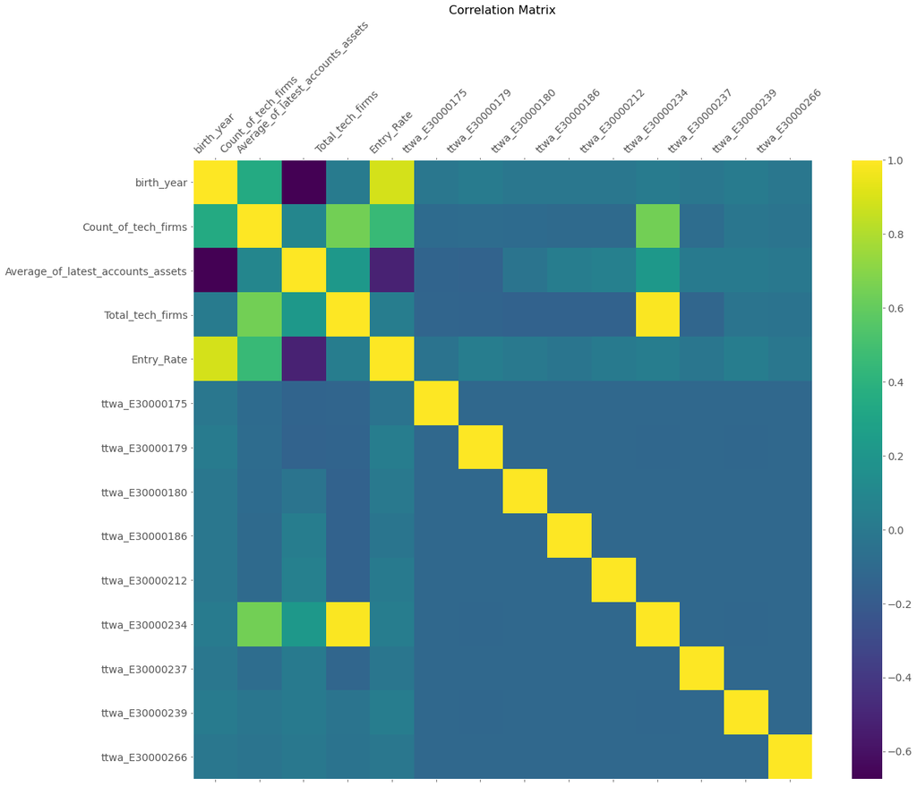

```python
df3_2 = df3.copy()

# intro dummy variables
df3_2.birth_year = df3_2.birth_year.astype("int")
df3_2_numeric = pd.get_dummies(df3_2)

# add dummies operation requirement
# Set the reference object is ttwa_E30000169（Birmingham）
# drop Birmingham for dummies variables comparasion
df3_2_numeric = df3_2_numeric.drop(['ttwa_E30000169'], axis=1)

# preprocess drop n/a value
df3_2_final = df3_2_numeric.dropna(subset = ["Average_of_latest_accounts_assets"])

# correlation analysis
df = df3_2_final
plt.rcParams["axes.grid"] = False
f = plt.figure(figsize=(19, 15))
plt.matshow(df.corr(), fignum=f.number)
plt.xticks(range(df.shape[1]), df.columns, fontsize=14, rotation=45)
plt.yticks(range(df.shape[1]), df.columns, fontsize=14)
cb = plt.colorbar()
cb.ax.tick_params(labelsize=14)
plt.title('Correlation Matrix', fontsize=16)
```

Then I introduce VIF method to help remove columns which might cause strong multicollinearity problem

```python
# VIF method
from statsmodels.stats.outliers_influence import variance_inflation_factor
from statsmodels.tools.tools import add_constant

def drop_column_using_vif_(df, list_var_not_to_remove, thresh=5):
    '''
    Calculates VIF each feature in a pandas dataframe, and repeatedly drop the columns with the highest VIF
    A constant must be added to variance_inflation_factor or the results will be incorrect

    :param df: the pandas dataframe containing only the predictor features, not the response variable
    :param list_var_not_to_remove: the list of variables that should not be removed even though it has a high VIF. For example, dummy (or indicator) variables represent a categorical variable with three or more categories.
    :param thresh: the max VIF value before the feature is removed from the dataframe
    :return: dataframe with multicollinear features removed
    '''
    while True:
        # adding a constatnt item to the data
        df_with_const = add_constant(df)

        vif_df = pd.Series([variance_inflation_factor(df_with_const.values, i)
               for i in range(df_with_const.shape[1])], name= "VIF",
              index=df_with_const.columns).to_frame()

        # drop the const
        vif_df = vif_df.drop('const').drop(list_var_not_to_remove)

        print('Max VIF:', vif_df.VIF.max())

        # if the largest VIF is above the thresh, remove a variable with the largest VIF
        if vif_df.VIF.max() > thresh:
            # If there are multiple variables with the maximum VIF, choose the first one
            index_to_drop = vif_df.index[vif_df.VIF == vif_df.VIF.max()].tolist()[0]
            print('Dropping: {}'.format(index_to_drop))
            df = df.drop(columns = index_to_drop)
        else:
            # No VIF is above threshold. Exit the loop
            break

    return df
```

```python
predictors_df3 = df3_2_final.drop('Entry_Rate', axis=1)
response_df3 = df3_2_final['Entry_Rate']

# this is a list of dummy variables that represent a categorical variable with three or more categories. They should not be removed even if it has a high VIF.
# list_var_not_to_remove = ['ttwa_E30000234', 'Count_of_tech_firms', 'Total_tech_firms']
list_var_not_to_remove = ["birth_year","ttwa_E30000234"]
df_predictors_select_VIF = drop_column_using_vif_(predictors_df3, list_var_not_to_remove, thresh=5)
print("The columns remaining after VIF selection are:")
print(df_predictors_select_VIF.columns)

hypo1_1_regressor_OLS = sm.OLS(endog=response_df3, exog=sm.add_constant(df_predictors_select_VIF)).fit()
hypo1_1_regressor_OLS.summary()
```

```
Max VIF: inf
Dropping: Total_tech_firms
Max VIF: 2.5658319318283667
The columns remaining after VIF selection are:
Index(['birth_year', 'Count_of_tech_firms',
       'Average_of_latest_accounts_assets', 'ttwa_E30000175', 'ttwa_E30000179',
       'ttwa_E30000180', 'ttwa_E30000186', 'ttwa_E30000212', 'ttwa_E30000234',
       'ttwa_E30000237', 'ttwa_E30000239', 'ttwa_E30000266'],
      dtype='object')
```

OLS Regression Results

| Dep. Variable: | Entry_Rate | R-squared: | 0.838 |
| --- | --- | --- | --- |
| Model: | OLS | Adj. R-squared: | 0.828 |
| Method: | Least Squares | F-statistic: | 81.90 |
| Date: | Tue, 27 Jul 2021 | Prob (F-statistic): | 2.53e-68 |
| Time: | 00:33:48 | Log-Likelihood: | 555.40 |
| No. Observations: | 203 | AIC: | -1085. |
| Df Residuals: | 190 | BIC: | -1042. |
| Df Model: | 12 |  |  |
| Covariance Type: | nonrobust |  |  |

|  | coef | std err | t | P>\|t\| | [0.025 | 0.975] |
| --- | --- | --- | --- | --- | --- | --- |
| const | -11.5268 | 0.668 | -17.259 | 0.000 | -12.844 | -10.209 |
| birth_year | 0.0058 | 0.000 | 17.358 | 0.000 | 0.005 | 0.006 |
| Count_of_tech_firms | 4.046e-06 | 7.6e-07 | 5.323 | 0.000 | 2.55e-06 | 5.55e-06 |
| Average_of_latest_accounts_assets | 3.257e-08 | 1.77e-08 | 1.838 | 0.068 | -2.39e-09 | 6.75e-08 |
| ttwa_E30000175 | -0.0012 | 0.005 | -0.240 | 0.811 | -0.011 | 0.009 |
| ttwa_E30000179 | 0.0041 | 0.005 | 0.807 | 0.421 | -0.006 | 0.014 |
| ttwa_E30000180 | 0.0022 | 0.005 | 0.422 | 0.673 | -0.008 | 0.012 |
| ttwa_E30000186 | -0.0014 | 0.005 | -0.277 | 0.782 | -0.012 | 0.009 |
| ttwa_E30000212 | 0.0022 | 0.005 | 0.428 | 0.669 | -0.008 | 0.012 |
| ttwa_E30000234 | -0.0199 | 0.006 | -3.234 | 0.001 | -0.032 | -0.008 |
| ttwa_E30000237 | -0.0008 | 0.005 | -0.156 | 0.877 | -0.011 | 0.009 |
| ttwa_E30000239 | 0.0007 | 0.005 | 0.142 | 0.887 | -0.009 | 0.011 |
| ttwa_E30000266 | -0.0008 | 0.005 | -0.148 | 0.883 | -0.011 | 0.009 |

| Omnibus: | 44.698 | Durbin-Watson: | 0.499 |
| --- | --- | --- | --- |
| Prob(Omnibus): | 0.000 | Jarque-Bera (JB): | 86.296 |
| Skew: | 1.074 | Prob(JB): | 1.82e-19 |
| Kurtosis: | 5.364 | Cond. No. | 1.04e+08 |

Notes:  
[1] Standard Errors assume that the covariance matrix of the errors is correctly specified.  
[2] The condition number is large, 1.04e+08. This might indicate that there are  
strong multicollinearity or other numerical problems.

Then, the residual analysis is conducted to test the regression performance

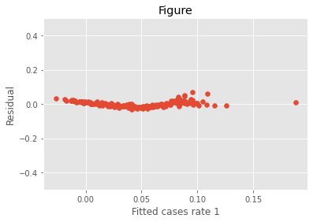

```python
plt.scatter(hypo1_1_regressor_OLS.fittedvalues, hypo1_1_regressor_OLS.resid)
# adding title and labels
plt.xlabel('Fitted cases rate 1')
plt.ylabel('Residual')
plt.title('Figure')
plt.ylim(-0.5,0.5)
plt.show()
```

```python
predictors_df3 = df3_2_final.drop('Average_of_latest_accounts_assets', axis=1)
response_df3 = df3_2_final['Average_of_latest_accounts_assets']

# this is a list of dummy variables that represent a categorical variable with three or more categories. They should not be removed even if it has a high VIF.
# list_var_not_to_remove = ['ttwa_E30000234', 'Count_of_tech_firms', 'Total_tech_firms']
list_var_not_to_remove = ["birth_year","ttwa_E30000234","Entry_Rate"]
df_predictors_select_VIF = drop_column_using_vif_(predictors_df3, list_var_not_to_remove, thresh=5)
print("The columns remaining after VIF selection are:")
print(df_predictors_select_VIF.columns)

hypo1_2_regressor_OLS = sm.OLS(endog=response_df3, exog=sm.add_constant(df_predictors_select_VIF)).fit()
hypo1_2_regressor_OLS.summary()
```

```
Max VIF: inf
Dropping: Total_tech_firms
Max VIF: 2.607020276192744
The columns remaining after VIF selection are:
Index(['birth_year', 'Count_of_tech_firms', 'Entry_Rate', 'ttwa_E30000175',
       'ttwa_E30000179', 'ttwa_E30000180', 'ttwa_E30000186', 'ttwa_E30000212',
       'ttwa_E30000234', 'ttwa_E30000237', 'ttwa_E30000239', 'ttwa_E30000266'],
      dtype='object')
```

OLS Regression Results

| Dep. Variable: | Average_of_latest_accounts_assets | R-squared: | 0.617 |
| --- | --- | --- | --- |
| Model: | OLS | Adj. R-squared: | 0.593 |
| Method: | Least Squares | F-statistic: | 25.51 |
| Date: | Tue, 27 Jul 2021 | Prob (F-statistic): | 1.73e-33 |
| Time: | 00:33:55 | Log-Likelihood: | -2533.4 |
| No. Observations: | 203 | AIC: | 5093. |
| Df Residuals: | 190 | BIC: | 5136. |
| Df Model: | 12 |  |  |
| Covariance Type: | nonrobust |  |  |

|  | coef | std err | t | P>\|t\| | [0.025 | 0.975] |
| --- | --- | --- | --- | --- | --- | --- |
| const | 3.429e+07 | 3.56e+06 | 9.635 | 0.000 | 2.73e+07 | 4.13e+07 |
| birth_year | -1.702e+04 | 1777.930 | -9.575 | 0.000 | -2.05e+04 | -1.35e+04 |
| Count_of_tech_firms | 14.1961 | 3.141 | 4.519 | 0.000 | 8.000 | 20.392 |
| Entry_Rate | 5.362e+05 | 2.92e+05 | 1.838 | 0.068 | -3.93e+04 | 1.11e+06 |
| ttwa_E30000175 | -3.437e+04 | 2.08e+04 | -1.651 | 0.100 | -7.54e+04 | 6690.439 |
| ttwa_E30000179 | -3.258e+04 | 2.06e+04 | -1.583 | 0.115 | -7.32e+04 | 8018.824 |
| ttwa_E30000180 | -2816.1829 | 2.08e+04 | -0.135 | 0.893 | -4.39e+04 | 3.82e+04 |
| ttwa_E30000186 | 1.849e+04 | 2.08e+04 | 0.888 | 0.375 | -2.26e+04 | 5.95e+04 |
| ttwa_E30000212 | 2.169e+04 | 2.08e+04 | 1.041 | 0.299 | -1.94e+04 | 6.28e+04 |
| ttwa_E30000234 | 4219.1182 | 2.56e+04 | 0.165 | 0.869 | -4.63e+04 | 5.47e+04 |
| ttwa_E30000237 | 1.075e+04 | 2.08e+04 | 0.517 | 0.606 | -3.03e+04 | 5.18e+04 |
| ttwa_E30000239 | 6566.5115 | 2.06e+04 | 0.319 | 0.750 | -3.4e+04 | 4.72e+04 |
| ttwa_E30000266 | -1716.2042 | 2.08e+04 | -0.082 | 0.934 | -4.28e+04 | 3.94e+04 |

| Omnibus: | 55.982 | Durbin-Watson: | 1.846 |
| --- | --- | --- | --- |
| Prob(Omnibus): | 0.000 | Jarque-Bera (JB): | 175.434 |
| Skew: | 1.114 | Prob(JB): | 8.03e-39 |
| Kurtosis: | 6.972 | Cond. No. | 2.11e+06 |

Notes:  
[1] Standard Errors assume that the covariance matrix of the errors is correctly specified.  
[2] The condition number is large, 2.11e+06. This might indicate that there are  
strong multicollinearity or other numerical problems.

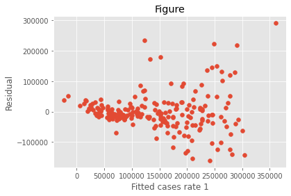

```python
plt.scatter(hypo1_2_regressor_OLS.fittedvalues, hypo1_2_regressor_OLS.resid)
# adding title and labels
plt.xlabel('Fitted cases rate 1')
plt.ylabel('Residual')
plt.title('Figure')
# plt.ylim(-0.5,0.5)
plt.show()
```

### 2.4.2 Hypothesis 2

Refer to: Dynamics_variable_it = a1 + b2#firms_it-n + b3industry mix_it-n + Xb_it-n + location_i + year_t + e_it (1)

$\ log_e{\ Dynamics\ Variable_{i,t}}\ =\ a_1 + b_1 \times firms_{i,t} + b_2 \times location_i + b_3 \times year_t$ (1)

```python
df3_3_final = df3_2_final.copy()

predictors_df3 = df3_3_final.drop({'Entry_Rate',"Average_of_latest_accounts_assets"}, axis=1)
response_df3 = np.log(df3_3_final['Entry_Rate'])

# this is a list of dummy variables that represent a categorical variable with three or more categories. They should not be removed even if it has a high VIF.
# list_var_not_to_remove = ['ttwa_E30000234', 'Count_of_tech_firms', 'Total_tech_firms']
list_var_not_to_remove = ["ttwa_E30000234","birth_year"]
df_predictors_select_VIF = drop_column_using_vif_(predictors_df3, list_var_not_to_remove, thresh=2.5)
print("The columns remaining after VIF selection are:")
print(df_predictors_select_VIF.columns)

hypo2_1_regressor_OLS = sm.OLS(endog=response_df3, exog=sm.add_constant(df_predictors_select_VIF)).fit()
hypo2_1_regressor_OLS.summary()
```

```
Max VIF: inf
Dropping: Total_tech_firms
Max VIF: 2.13351053449709
The columns remaining after VIF selection are:
Index(['birth_year', 'Count_of_tech_firms', 'ttwa_E30000175', 'ttwa_E30000179',
       'ttwa_E30000180', 'ttwa_E30000186', 'ttwa_E30000212', 'ttwa_E30000234',
       'ttwa_E30000237', 'ttwa_E30000239', 'ttwa_E30000266'],
      dtype='object')
```

OLS Regression Results

| Dep. Variable: | Entry_Rate | R-squared: | 0.932 |
| --- | --- | --- | --- |
| Model: | OLS | Adj. R-squared: | 0.928 |
| Method: | Least Squares | F-statistic: | 238.5 |
| Date: | Tue, 27 Jul 2021 | Prob (F-statistic): | 3.43e-105 |
| Time: | 00:34:53 | Log-Likelihood: | -9.0648 |
| No. Observations: | 203 | AIC: | 42.13 |
| Df Residuals: | 191 | BIC: | 81.89 |
| Df Model: | 11 |  |  |
| Covariance Type: | nonrobust |  |  |

|  | coef | std err | t | P>\|t\| | [0.025 | 0.975] |
| --- | --- | --- | --- | --- | --- | --- |
| const | -310.4470 | 6.992 | -44.399 | 0.000 | -324.239 | -296.655 |
| birth_year | 0.1529 | 0.003 | 43.878 | 0.000 | 0.146 | 0.160 |
| Count_of_tech_firms | 2.804e-05 | 1.13e-05 | 2.489 | 0.014 | 5.82e-06 | 5.03e-05 |
| ttwa_E30000175 | -0.4938 | 0.082 | -5.986 | 0.000 | -0.657 | -0.331 |
| ttwa_E30000179 | -0.1491 | 0.082 | -1.829 | 0.069 | -0.310 | 0.012 |
| ttwa_E30000180 | 0.1377 | 0.082 | 1.669 | 0.097 | -0.025 | 0.300 |
| ttwa_E30000186 | 0.1193 | 0.083 | 1.446 | 0.150 | -0.043 | 0.282 |
| ttwa_E30000212 | 0.2416 | 0.083 | 2.928 | 0.004 | 0.079 | 0.404 |
| ttwa_E30000234 | -0.2003 | 0.099 | -2.028 | 0.044 | -0.395 | -0.005 |
| ttwa_E30000237 | -0.0440 | 0.082 | -0.533 | 0.595 | -0.207 | 0.119 |
| ttwa_E30000239 | 0.0074 | 0.082 | 0.091 | 0.928 | -0.154 | 0.168 |
| ttwa_E30000266 | 0.0248 | 0.083 | 0.300 | 0.765 | -0.138 | 0.188 |

| Omnibus: | 6.590 | Durbin-Watson: | 1.008 |
| --- | --- | --- | --- |
| Prob(Omnibus): | 0.037 | Jarque-Bera (JB): | 6.880 |
| Skew: | 0.316 | Prob(JB): | 0.0321 |
| Kurtosis: | 3.643 | Cond. No. | 1.04e+06 |

Notes:  
[1] Standard Errors assume that the covariance matrix of the errors is correctly specified.  
[2] The condition number is large, 1.04e+06. This might indicate that there are  
strong multicollinearity or other numerical problems.

The result can be writen in the below formula:

$ log_e{\ Dynamics\ Variable_{i,t}} = -310 + 2.8e^{-5} \times firms_{i,t} + b_2 \times location_i + 0.15 \times year_t$

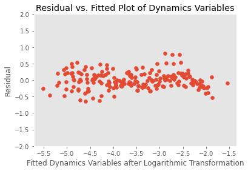

```python
plt.scatter(hypo2_1_regressor_OLS.fittedvalues, hypo2_1_regressor_OLS.resid)
# adding title and labels
plt.xlabel('Fitted Dynamics Variables after Logarithmic Transformation')
plt.ylabel('Residual')
plt.title('Residual vs. Fitted Plot of Dynamics Variables')
plt.ylim(-2,2)
plt.show()
```

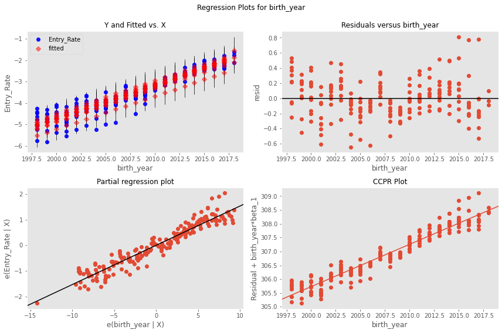

```python
fig1 = plt.figure(figsize=(12,8))
fig1 = sm.graphics.plot_regress_exog(hypo2_1_regressor_OLS, 'birth_year', fig=fig1)
```

The second formula:

Refer to: Firm_performance_it = c1 + c2#firms_it-n + c3dynamics_it-n + c4industry mix_it-n + Xc_it-n + location_i + year_t + u_it (2)

$\ log_e\ Firm\ Performance_{i,t}\ =\ c_1 + d_1 \times firms_{i,t} + d_2 \times dynamics_{i,t} + d_3 \times location_i + d_4 \times year_t$ (2)

```python
df3_3_final = df3_2_final.copy()

predictors_df3 = df3_3_final.drop({"Average_of_latest_accounts_assets"}, axis=1)
response_df3 = np.log(df3_3_final['Average_of_latest_accounts_assets'])

# this is a list of dummy variables that represent a categorical variable with three or more categories. They should not be removed even if it has a high VIF.
# list_var_not_to_remove = ['ttwa_E30000234', 'Count_of_tech_firms', 'Total_tech_firms']
list_var_not_to_remove = ["ttwa_E30000234","birth_year","Entry_Rate","Count_of_tech_firms"]
df_predictors_select_VIF = drop_column_using_vif_(predictors_df3, list_var_not_to_remove, thresh=2.5)
print("The columns remaining after VIF selection are:")
print(df_predictors_select_VIF.columns)

hypo2_2_regressor_OLS = sm.OLS(endog=response_df3, exog=sm.add_constant(df_predictors_select_VIF)).fit()
hypo2_2_regressor_OLS.summary()
```

```
Max VIF: inf
Dropping: Total_tech_firms
Max VIF: 1.8437386819351917
The columns remaining after VIF selection are:
Index(['birth_year', 'Count_of_tech_firms', 'Entry_Rate', 'ttwa_E30000175',
       'ttwa_E30000179', 'ttwa_E30000180', 'ttwa_E30000186', 'ttwa_E30000212',
       'ttwa_E30000234', 'ttwa_E30000237', 'ttwa_E30000239', 'ttwa_E30000266'],
      dtype='object')
```

OLS Regression Results

| Dep. Variable: | Average_of_latest_accounts_assets | R-squared: | 0.745 |
| --- | --- | --- | --- |
| Model: | OLS | Adj. R-squared: | 0.729 |
| Method: | Least Squares | F-statistic: | 46.37 |
| Date: | Tue, 27 Jul 2021 | Prob (F-statistic): | 6.23e-50 |
| Time: | 00:40:53 | Log-Likelihood: | -99.816 |
| No. Observations: | 203 | AIC: | 225.6 |
| Df Residuals: | 190 | BIC: | 268.7 |
| Df Model: | 12 |  |  |
| Covariance Type: | nonrobust |  |  |

|  | coef | std err | t | P>\|t\| | [0.025 | 0.975] |
| --- | --- | --- | --- | --- | --- | --- |
| const | 147.5047 | 22.122 | 6.668 | 0.000 | 103.868 | 191.142 |
| birth_year | -0.0675 | 0.011 | -6.111 | 0.000 | -0.089 | -0.046 |
| Count_of_tech_firms | 0.0001 | 1.95e-05 | 5.773 | 0.000 | 7.42e-05 | 0.000 |
| Entry_Rate | -8.9585 | 1.814 | -4.940 | 0.000 | -12.536 | -5.381 |
| ttwa_E30000175 | -0.2359 | 0.129 | -1.823 | 0.070 | -0.491 | 0.019 |
| ttwa_E30000179 | -0.2070 | 0.128 | -1.618 | 0.107 | -0.459 | 0.045 |
| ttwa_E30000180 | 0.0600 | 0.129 | 0.464 | 0.643 | -0.195 | 0.315 |
| ttwa_E30000186 | 0.1323 | 0.129 | 1.023 | 0.308 | -0.123 | 0.387 |
| ttwa_E30000212 | 0.2389 | 0.129 | 1.845 | 0.067 | -0.016 | 0.494 |
| ttwa_E30000234 | 0.0065 | 0.159 | 0.041 | 0.967 | -0.307 | 0.320 |
| ttwa_E30000237 | 0.0750 | 0.129 | 0.580 | 0.563 | -0.180 | 0.330 |
| ttwa_E30000239 | -0.0467 | 0.128 | -0.365 | 0.716 | -0.299 | 0.206 |
| ttwa_E30000266 | 0.0912 | 0.129 | 0.704 | 0.482 | -0.164 | 0.347 |

| Omnibus: | 103.810 | Durbin-Watson: | 1.682 |
| --- | --- | --- | --- |
| Prob(Omnibus): | 0.000 | Jarque-Bera (JB): | 1355.690 |
| Skew: | -1.582 | Prob(JB): | 4.13e-295 |
| Kurtosis: | 15.259 | Cond. No. | 2.11e+06 |

Notes:  
[1] Standard Errors assume that the covariance matrix of the errors is correctly specified.  
[2] The condition number is large, 2.11e+06. This might indicate that there are  
strong multicollinearity or other numerical problems.

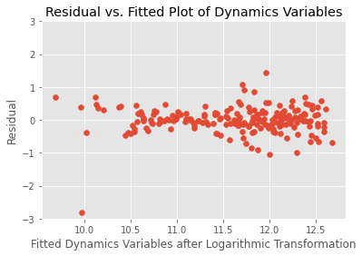

```python
plt.scatter(hypo2_2_regressor_OLS.fittedvalues, hypo2_2_regressor_OLS.resid)
# adding title and labels
plt.xlabel('Fitted Dynamics Variables after Logarithmic Transformation')
plt.ylabel('Residual')
plt.title('Residual vs. Fitted Plot of Dynamics Variables')
plt.ylim(-3,3)
plt.show()
```

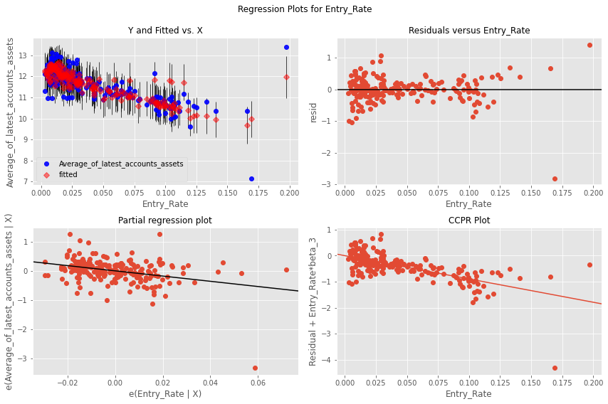

```python
fig2 = plt.figure(figsize=(12,8))
fig2 = sm.graphics.plot_regress_exog(hypo2_2_regressor_OLS, 'Entry_Rate', fig=fig2)
```